# Klasse-F slides

Klasse F versterker

met trilkring derde harmonische

Jan Genoe

September 2025

###### Overzicht

- **Inleiding** - Wat zijn Klasse F versterkers?
- **Theoretische achtergrond** - Werkingsprincipe en vergelijking Klasse C
- **Circuitanalyse** - Praktisch schema en componenten
- **Simulaties** - SPICE analyse van het gedrag
- **Harmonische filtering** - Rol van de extra LC-kringen
- **Efficiëntie** - Prestatievoordelen
- **Alternatieve schema's** - Varianten en toepassingen
- **Conclusies** - Samenvatting en praktische overwegingen

## Inleiding: Wat zijn Klasse F versterkers?

###### Definitie

Klasse F versterkers zijn **hoogfrequent resonante versterkers** die:

- Werken met **harmonische filtering**
- Gebruiken **meerdere LC-kringen** voor optimalisatie
- Hebben een **zeer hoge efficiëntie** (theoretisch 100%)
- Zijn optimaal voor **enkelvoudige frequenties**

###### Belangrijkste kenmerken

- 🎯 **Resonant**: Werken op één specifieke frequentie
- ⚡ **Efficiënt**: Minimaal energieverlies
- 🔧 **Selectief**: Smalle bandbreedte (~1% van f<sub>o</sub>)
- 📡 **RF toepassingen**: Zenders, oscillatoren

###### Verschil tussen Klasse C en Klasse F

Klasse C versterker

- **Eenvoudig**: Één LC-kring
- **Basis resonantie**: Werkt op fundamentele frequentie
- **Beperkte efficiëntie**: ~85-90%

Klasse F versterker

- **Uitgebreid**: Meerdere LC-kringen
- **Harmonische optimalisatie**: Controle over 2e en 3e harmonische
- **Hogere efficiëntie**: Tot ~95% praktisch

###### Waarom Klasse F?

De extra LC-kringen in Klasse F zorgen voor:

- **Betere golfvorm**: Minder vervorming
- **Hogere efficiëntie**: Minder energieverlies
- **Meer vermogen**: Bij dezelfde transistor

###### Basisschema van de klasse F versterker

[figure not shown]

###### Belangrijke knopen

In het schema identificeren we:

- **Knoop 1**: Ingang (AC koppeling)
- **Knoop 2**: Collector (fundamentele + harmonischen)
- **Knoop 3**: Voeding (V<sub>dd</sub>)
- **Knoop 5**: Uitgang (gefilterde fundamentele)

###### Sleutelcomponenten

- **Q1**: driving transistor
- **L1, C1**: Fundamentele resonantiekring (f<sub>o</sub>)
- **L3, C3**: 3e harmonische filter (3×f<sub>o</sub>)

###### Spice code van de klasse F versterker

```
* klasse F basiscircuit
Q_Q1         2 1 0 Q2
L_L1         5 3   1uH
C_C1         5 3   10n
R_R1         5 3   60
V_V3         3 0   11V
V_V5         1 0   sin(0.7 0.8 1591500) DC=0.7
C_C3         5 2   10n
L_L3         5 2   0.111uH
.model Q2  NPN(Is=14.34f BF=200 RB=200 )
```

###### Spanningen op de verschillende knopen van de klasse F versterker

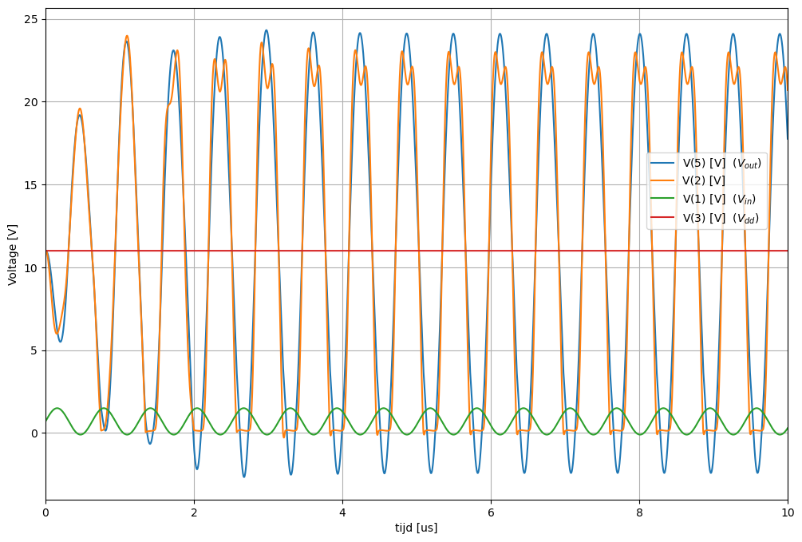

###### Simulatieparameters

- **Tijd**: 10 μs (meerdere perioden)
- **Frequentie**: ~1591 kHz fundamenteel
- **Temperatuur**: 25°C

###### Verloop van de spanning over de eerste (LC1) en over de derde (LC3) harmonische.

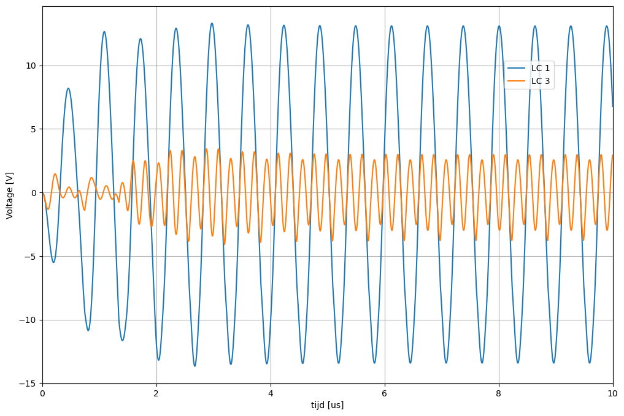

###### Verloop van de collector current

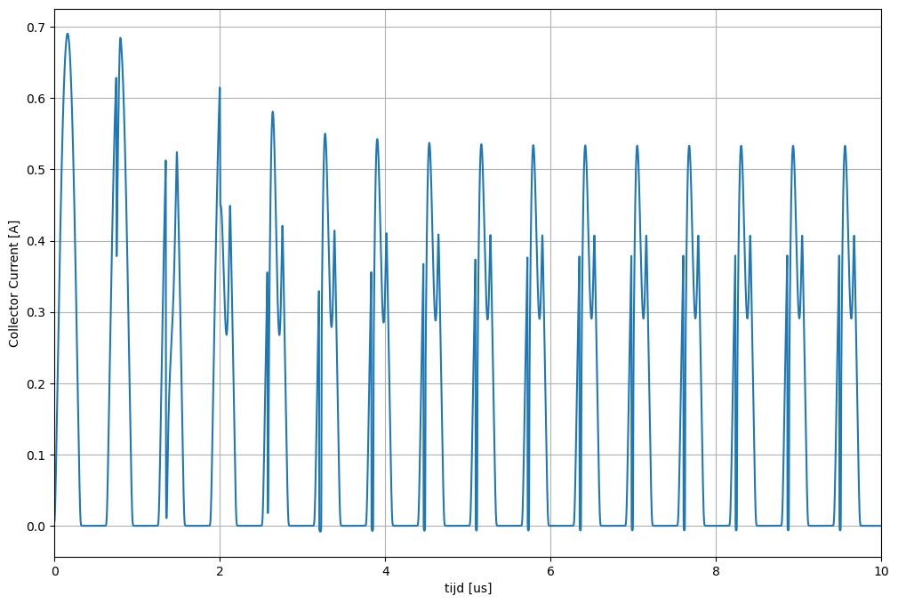

###### Effect van de saturatiespanning

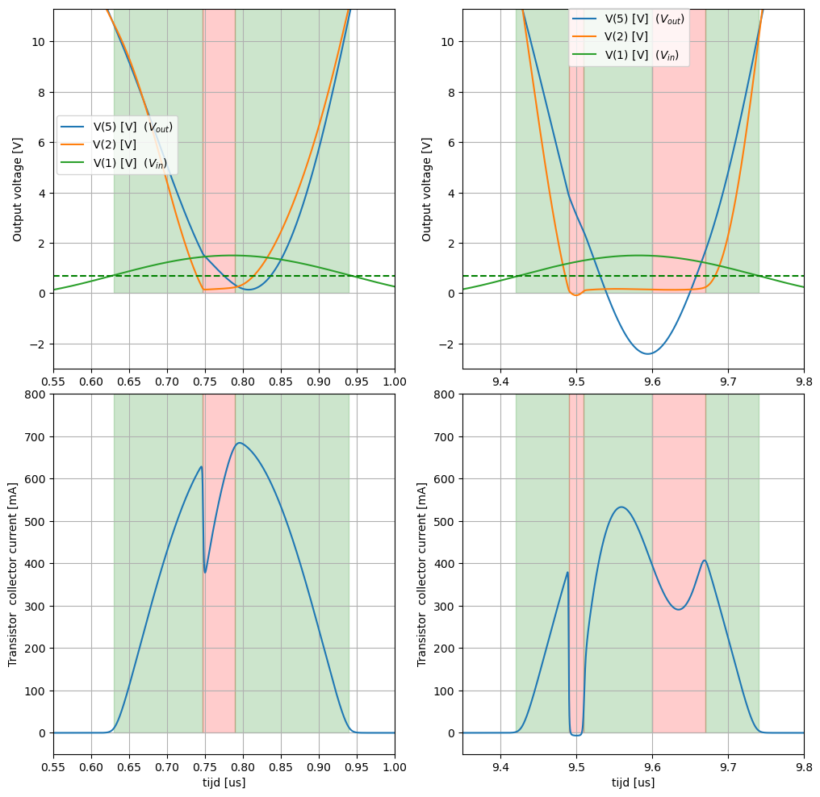

###### Analyse van de Simulatieresultaten

## Analyse van de Simulatieresultaten

###### Spanningsverschillen

- **Knoop 2 vs Knoop 5**: Toont effect van 3e harmonische filter
- **Kleurgecodeerde zones**:
  - 🟢 **Groen**: Transistor stroom niet gereduceerd door saturatie
    - Transistor in het voorwaarts actief gebied
  - 🔴 **Rood**: Transistor stroom gereduceerd door saturatie
    - lage collector spanning

###### Harmonische werking

De 3e harmonische filter zorgt voor:

- **Golfvorming**: Verbeterde collector spanning
- **Efficiëntie**: Verminderd energieverlies
- **Vermogen**: Optimale energieoverdracht

###### Efficiëntie van Klasse F Versterkers

## Efficiëntie van Klasse F Versterkers

###### Theoretische efficiëntie

- **Klasse A**: Max 50%
- **Klasse B**: Max 78.5%
- **Klasse C**: 85-90%
- **Klasse F**: Tot 100% (theoretisch)

###### Praktische voordelen

- **Energiebesparing**: Lagere operationele kosten
- **Koeling**: Minder warmteontwikkeling
- **Batterijduur**: Langer bij draagbare apparaten
- **Vermogen**: Meer output bij zelfde transistor
- ⚡ **Voordeel**: Hogere efficiëntie
- 💰 **Nadeel**: Meer componenten (kosten)
- 📐 **Nadeel**: Complexer ontwerp
- 📏 **Nadeel**: Meer PCB ruimte

###### klasse F versterker waarbij de uitgang oscilleert rond de grond

[figure not shown]

###### Klasse F versterker met oscillatie rond de grond

```
* klasseF
Q_Q1         2 1 0 Q2
L_L1         0 3   1uH
C_C1         0 3   10n
R_R1         0 3   100
V_V3         4 0   10V
V_V5         1 0   sin(0.4 0.8 1591500) DC=0.4
C_C3         5 3   10n
L_L3         6 3   0.111uH
R_R3         6 5   0.001
L_L2         2 4   2mH
C_C2         2 5   1000n
.model Q2  NPN(Is=14.34f BF=200 Rb=100 )
```

###### Spice simulatie van de Klasse F waarbij de uitgang oscilleert rond de grond

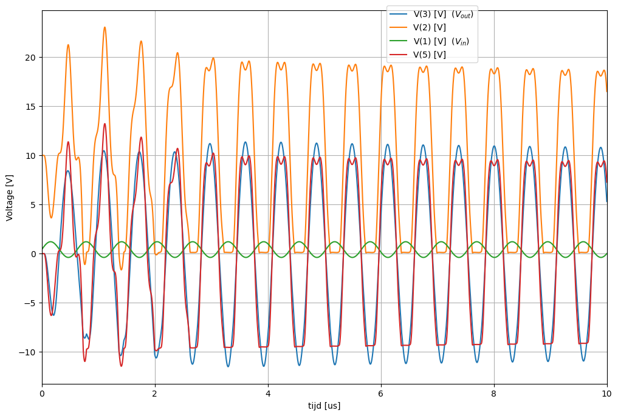

###### Waarom een alternatief schema?

Het alternatieve schema biedt:

- **Aarding**: Oscillatie rond 0V i.p.v. VCC
- **Eenvoud**: Gemakkelijkere metingen
- **Praktisch**: Beter voor sommige toepassingen

###### Spice simulatie van de Klasse F waarbij de uitgang oscilleert rond de grond. Verloop van de spanning over de eerste (LC1) en over de derde (LC3) harmonische

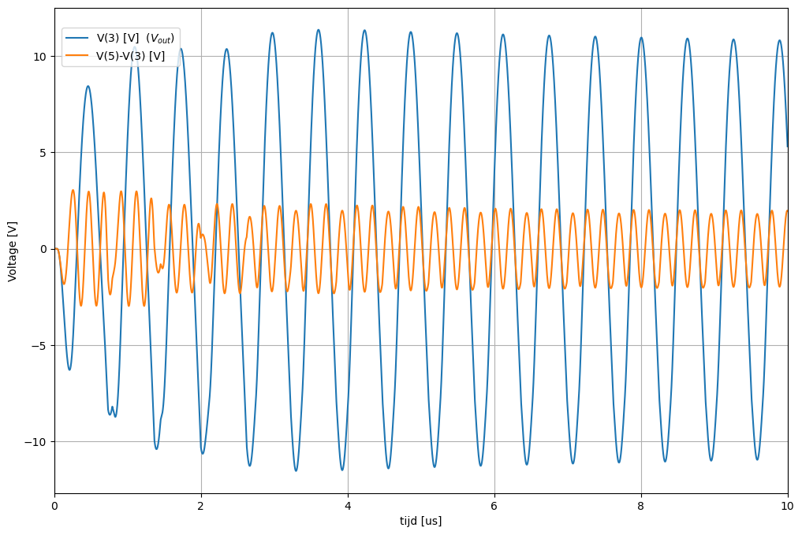

###### RF Zenders

- FM radio stations
- TV zenders
- Mobiele basisstations
- Satellietcommunicatie

###### Industriële toepassingen

- RF verwarming
- Plasma generatoren
- Medische diathermie
- Inductieve verwarming

###### Ontwerpoverwegingen

- **Frequentieselectie**: Fundamenteel + harmonischen
- **Q-factor**: Bandbreedte vs efficiëntie
- **Componenttoleranties**: Precisie vereist
- **Thermisch management**: Koeling

###### Samenvatting en Conclusies

## Samenvatting en Conclusies

###### Klasse F kenmerken

- **Hoogfrequent**: Resonante versterkers voor vaste frequenties
- **Efficiënt**: Tot 95% praktische efficiëntie mogelijk
- **Harmonisch**: 3e harmonische filter is essentieel
- **Selectief**: Smalle bandbreedte (~1% van f<sub>o</sub>)

###### Voordelen vs Nadelen

| ✅ **Voordelen** | ❌ **Nadelen** |
| --- | --- |
| Zeer hoge efficiëntie | Meer componenten |
| Minder warmte | Complexer ontwerp |
| Meer vermogen | Hogere kosten |
| Energiebesparing | Meer PCB ruimte |

I would rather have questions that can't be answered  
than answers that can't be questioned.

Richard Feynman